# UTS MPDW Praktikum

Muhammad Fahrezi Maulana_G1401221103

2024-10-10

```r
library(readxl)
dt <- read_excel("C:/Users/DSITD/Downloads/dataset_ujian_praktikum.xlsx")
dt
```

```
## # A tibble: 500 × 2
##       No Voltage
##    <dbl>   <dbl>
##  1     1    323.
##  2     2    322.
##  3     3    321.
##  4     4    322.
##  5     5    324.
##  6     6    323.
##  7     7    323.
##  8     8    323.
##  9     9    322.
## 10    10    322.
## # ℹ 490 more rows
```

```r
library("forecast")
```

```r
library("graphics")
library("TTR")
library("TSA")
library("MASS")
```

# Membuat data menjadi time series

```r
Voltage <- dt$Voltage
dt.ts <- ts(dt$Voltage)
```

# Plot data time series

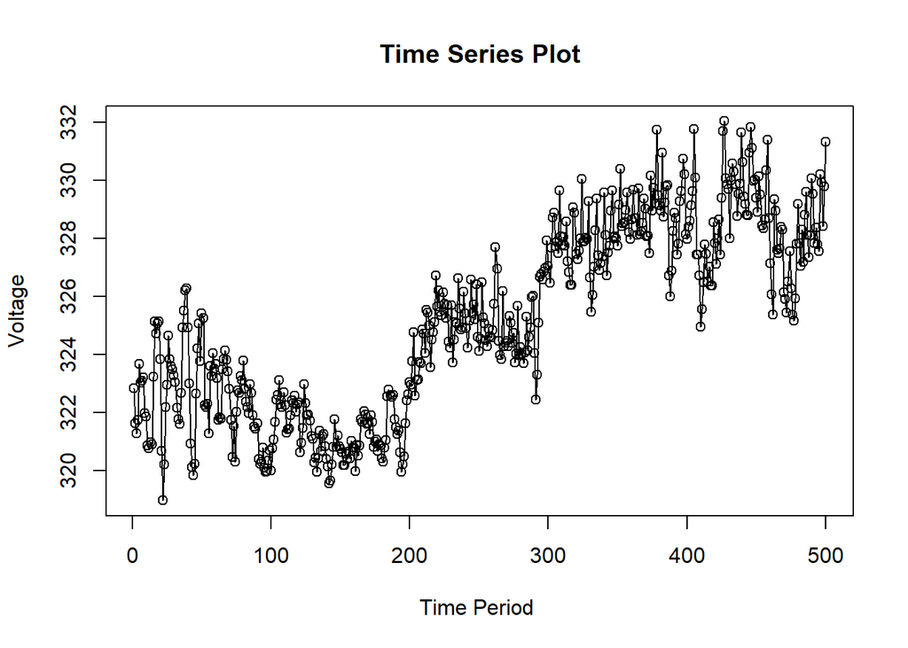

```r
ts.plot(dt.ts, xlab="Time Period ", ylab="Voltage",
        main = "Time Series Plot")
points(dt.ts)
```

### Pembagian Data

```r
train <- dt[1:293,]
test <- dt[294:500,]
train.ts <- ts(train$Voltage)
test.ts <- ts(test$Voltage)
```

### Eksplorasi Data

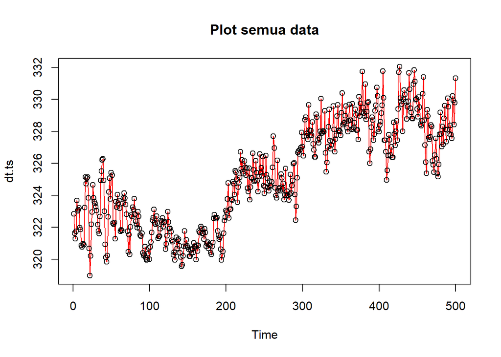

```r
#eksplorasi keseluruhan data
plot(dt.ts, col="red",main="Plot semua data")
points(dt.ts)
```

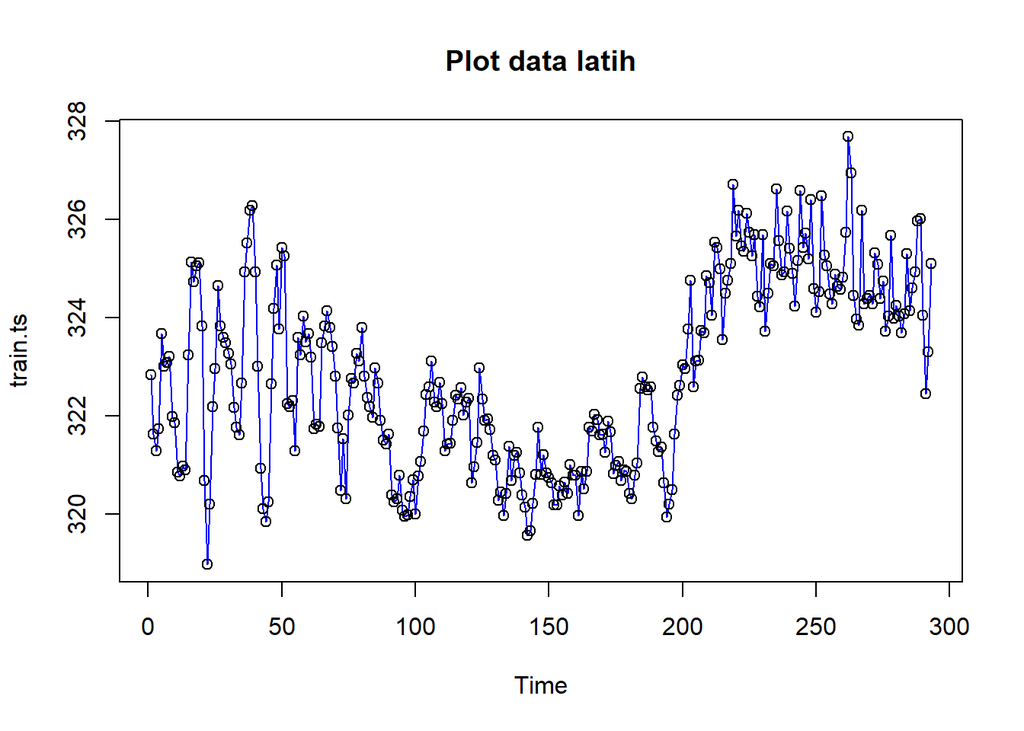

```r
#eksplorasi data latih
plot(train.ts, col="blue",main="Plot data latih")
points(train.ts)
```

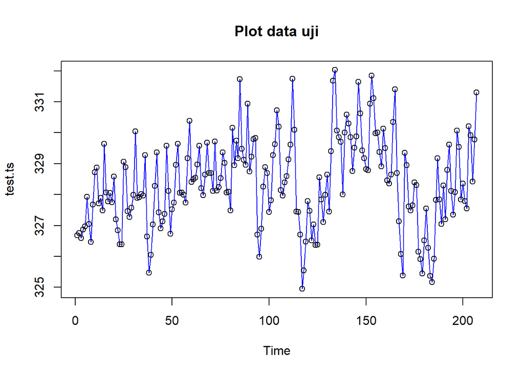

```r
#eksplorasi data uji
plot(test.ts, col="blue",main="Plot data uji")
points(test.ts)
```

## Single Moving Average (SMA)

```r
data.sma<-SMA(train.ts, n=3)
data.sma
```

```
## Time Series:
## Start = 1
## End = 293
## Frequency = 1
##   [1]       NA       NA 321.9200 321.5533 322.2367 322.8133 323.2633 323.1100
##   [9] 322.7667 322.3567 321.5700 321.1667 320.8767 320.8933 321.7133 323.0967
##  [17] 324.3700 324.9767 324.9733 324.6767 323.2200 321.1700 319.9600 320.4600
##  [25] 321.7867 323.2700 323.8200 324.0333 323.6433 323.4567 323.2767 322.8367
##  [33] 322.3333 321.8533 322.0233 323.0800 324.3800 325.5533 326.0000 325.8033
##  [41] 324.7400 322.9567 321.3533 320.3000 320.0733 320.9200 322.3700 323.9767
##  [49] 324.3500 324.7600 324.8233 324.3133 323.2367 322.2533 321.9333 322.4033
##  [57] 322.7167 323.6333 323.6000 323.7433 323.4633 322.8733 322.2600 321.7900
##  [65] 322.3767 323.0433 323.8300 323.9333 323.7900 323.3467 322.6633 321.6867
##  [73] 321.2600 320.7800 321.2933 321.7000 322.4833 322.9000 323.0200 323.3967
##  [81] 323.2433 322.9967 322.4633 322.1867 322.3900 322.5467 322.5267 322.0333
```

[output cut: 26 more lines]

```r
data.ramal<-c(NA,data.sma)
data.ramal
```

```
##   [1]       NA       NA       NA 321.9200 321.5533 322.2367 322.8133 323.2633
##   [9] 323.1100 322.7667 322.3567 321.5700 321.1667 320.8767 320.8933 321.7133
##  [17] 323.0967 324.3700 324.9767 324.9733 324.6767 323.2200 321.1700 319.9600
##  [25] 320.4600 321.7867 323.2700 323.8200 324.0333 323.6433 323.4567 323.2767
##  [33] 322.8367 322.3333 321.8533 322.0233 323.0800 324.3800 325.5533 326.0000
##  [41] 325.8033 324.7400 322.9567 321.3533 320.3000 320.0733 320.9200 322.3700
##  [49] 323.9767 324.3500 324.7600 324.8233 324.3133 323.2367 322.2533 321.9333
##  [57] 322.4033 322.7167 323.6333 323.6000 323.7433 323.4633 322.8733 322.2600
##  [65] 321.7900 322.3767 323.0433 323.8300 323.9333 323.7900 323.3467 322.6633
##  [73] 321.6867 321.2600 320.7800 321.2933 321.7000 322.4833 322.9000 323.0200
##  [81] 323.3967 323.2433 322.9967 322.4633 322.1867 322.3900 322.5467 322.5267
##  [89] 322.0333 321.6233 321.5300 321.1567 320.7600 320.3200 320.4533 320.4000
##  [97] 320.2800 320.0133 320.1033 320.3533 320.3600 320.5000 320.6233 321.1833
## [105] 321.7367 322.2433 322.7200 322.6667 322.5300 322.3867 322.3800 322.0833
## [113] 321.6633 321.3933 321.5967 321.9300 322.2267 322.4500 322.3133 322.2967
```

[output cut: 22 more lines]

```r
data.gab<-cbind(aktual=c(train.ts,rep(NA,50)),pemulusan=c(data.sma,rep(NA,50)),ramalan=c(data.ramal,rep(data.ramal[length(data.ramal)],49)))
data.gab
```

```
##        aktual pemulusan  ramalan
##   [1,] 322.84        NA       NA
##   [2,] 321.63        NA       NA
##   [3,] 321.29  321.9200       NA
##   [4,] 321.74  321.5533 321.9200
##   [5,] 323.68  322.2367 321.5533
##   [6,] 323.02  322.8133 322.2367
##   [7,] 323.09  323.2633 322.8133
##   [8,] 323.22  323.1100 323.2633
##   [9,] 321.99  322.7667 323.1100
##  [10,] 321.86  322.3567 322.7667
##  [11,] 320.86  321.5700 322.3567
##  [12,] 320.78  321.1667 321.5700
##  [13,] 320.99  320.8767 321.1667
##  [14,] 320.91  320.8933 320.8767
```

[output cut: 329 more lines]

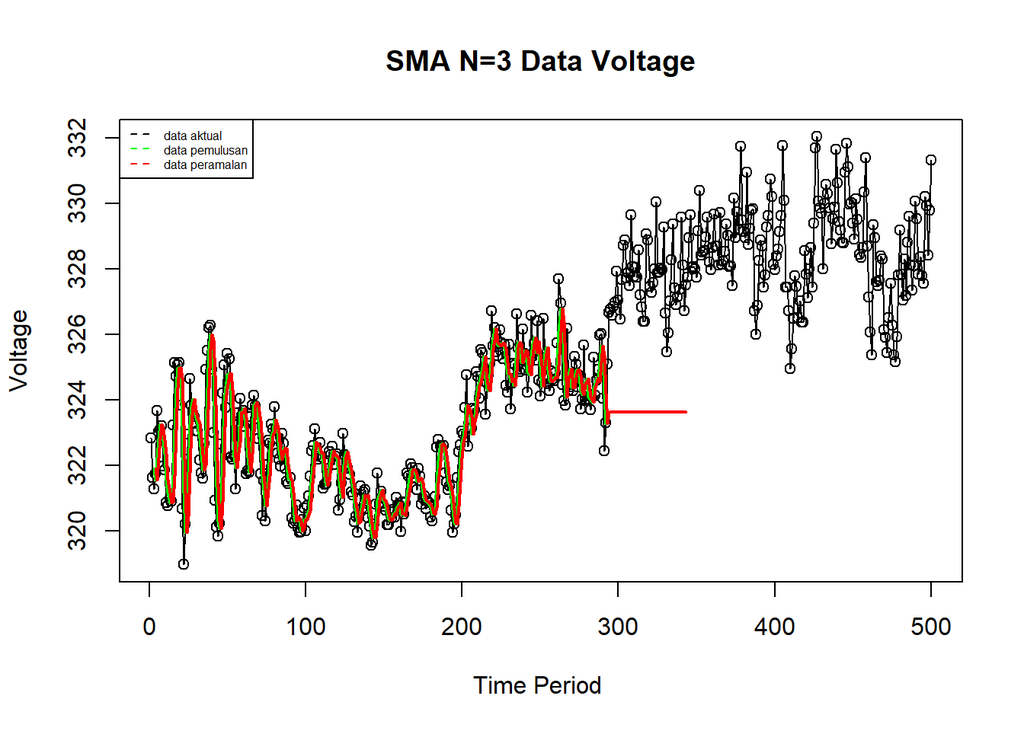

```r
ts.plot(dt.ts, xlab="Time Period ", ylab="Voltage", main= "SMA N=3 Data Voltage")
points(dt.ts)
lines(data.gab[,2],col="green",lwd=2)
lines(data.gab[,3],col="red",lwd=2)
legend("topleft",c("data aktual","data pemulusan","data peramalan"), lty=8, col=c("black","green","red"), cex=0.5)
```

### Menghitung nilai keakuratan data latih

```r
error_train.sma = train.ts-data.ramal[1:length(train.ts)]
SSE_train.sma = sum(error_train.sma[5:length(train.ts)]^2)
MSE_train.sma = mean(error_train.sma[5:length(train.ts)]^2)
MAPE_train.sma = mean(abs((error_train.sma[5:length(train.ts)]/train.ts[5:length(train.ts)])*100))

akurasi_train.sma <- matrix(c(SSE_train.sma, MSE_train.sma, MAPE_train.sma))
row.names(akurasi_train.sma)<- c("SSE", "MSE", "MAPE")
colnames(akurasi_train.sma) <- c("Akurasi m = 3")
akurasi_train.sma
```

```
##      Akurasi m = 3
## SSE    365.6564444
## MSE      1.2652472
## MAPE     0.2561269
```

Dalam hal ini nilai MAPE data latih pada metode pemulusan SMA kurang dari 2%, nilai ini dapat dikategorikan sebagai nilai akurasi yang sangat baik. Selanjutnya dilakukan perhitungan nilai MAPE data uji pada metde pemulusan SMA.

### Menghitung nilai keakuratan data uji

```r
error_test.sma = test.ts-data.gab[294:333,3]
```

```r
SSE_test.sma = sum(error_test.sma^2)
MSE_test.sma = mean(error_test.sma^2)
MAPE_test.sma = mean(abs((error_test.sma/test.ts*100)))

akurasi_test.sma <- matrix(c(SSE_test.sma, MSE_test.sma, MAPE_test.sma))
row.names(akurasi_test.sma)<- c("SSE", "MSE", "MAPE")
colnames(akurasi_test.sma) <- c("Akurasi m = 4")
akurasi_test.sma
```

```
##      Akurasi m = 4
## SSE    5127.907400
## MSE      24.772500
## MAPE      1.449607
```

## Proses MA(1)

### Plot ACF

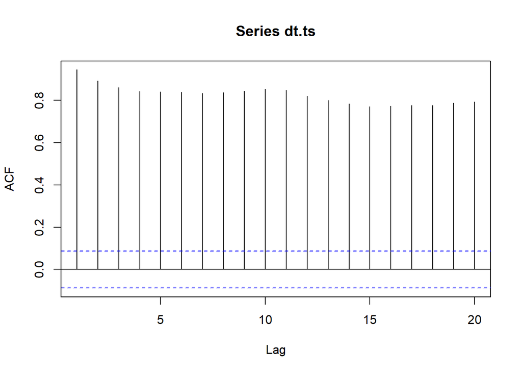

```r
acf(dt.ts,lag.max = 20)
```

### Plot PACF

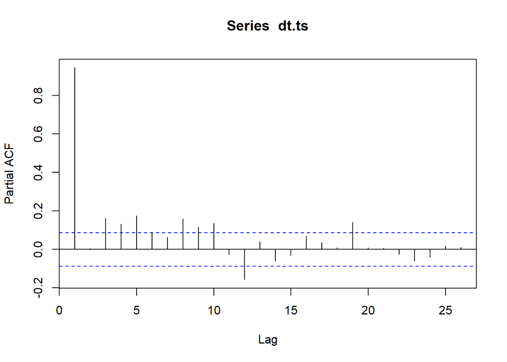

```r
pacf(dt.ts)
```

### Plot EACF

```r
TSA::eacf(dt.ts)
```

```
## AR/MA
##   0 1 2 3 4 5 6 7 8 9 10 11 12 13
## 0 x x x x x x x x x x x  x  x  x
## 1 o x x x o o o o o x x  o  o  o
## 2 o o o x o o o o o o x  x  o  o
## 3 x x o x o o o o o o x  x  o  o
## 4 x x x x o o x o o o x  x  o  o
## 5 x x x x o o o o o o x  x  o  x
## 6 x o x x x o o o o o x  x  o  x
## 7 x x x x x x o o o o x  o  o  x
```

Berdasarkan pola segitiga nol pada plot EACF, terlihat bahwa segitiga nol berada pada ordo AR(2) dan ordo MA(1)

## Proses AR

```r
n<-length(dt.ts)
n
```

```
## [1] 500
```

```r
ar <- c(1:n)
for (i in 2:n) {ar[i]<-dt.ts[i]+0.7*ar[i-1]}
ar
```

```
##   [1]    1.0000  322.3300  546.9210  704.5847  816.8893  894.8425  949.4798
##   [8]  987.8558 1013.4891 1031.3024 1042.7716 1050.7202 1056.4941 1060.4559
##  [15] 1065.5591 1071.0314 1074.4520 1077.1764 1079.1535 1079.2474 1076.1632
##  [22] 1072.2942 1070.8160 1071.7612 1073.1928 1075.8950 1076.9665 1077.4765
##  [29] 1077.7236 1077.6865 1077.4406 1076.3784 1075.2349 1074.2844 1074.6791
##  [36] 1077.2154 1079.5708 1081.8995 1083.6097 1083.4568 1081.4297 1077.9308
##  [43] 1074.6716 1072.1201 1070.7341 1072.1738 1074.7217 1077.3752 1077.9426
##  [50] 1079.9898 1081.2529 1079.1270 1077.5889 1076.6222 1074.9256 1076.0579
##  [57] 1076.4905 1077.5834 1077.8184 1078.1529 1077.9070 1076.2749 1075.2324
##  [64] 1074.4527 1075.6169 1076.7718 1077.8903 1078.3332 1078.2432 1077.5903
##  [71] 1076.0732 1073.7312 1073.1519 1071.5263 1072.0884 1073.2219 1073.9253
##  [78] 1075.0177 1075.6324 1076.7427 1076.5299 1075.9509 1075.3656 1074.7359
##  [85] 1075.3052 1075.3836 1074.6885 1073.7920 1073.0944 1072.8061 1071.3542
##  [92] 1070.1980 1069.4586 1069.4110 1068.6777 1068.0344 1067.6141 1067.6899
##  [99] 1068.0929 1067.6750 1068.1525 1068.7868 1069.8407 1071.3285 1072.5300
```

[output cut: 57 more lines]

### Plot ACF

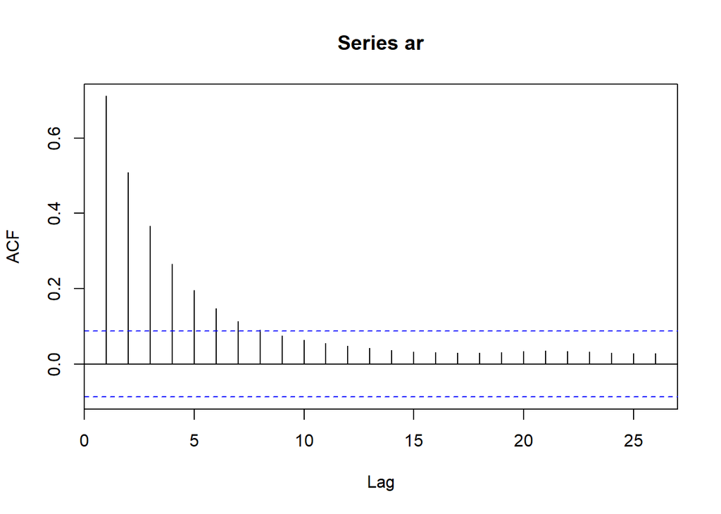

```r
acf(ar)
```

### Plot PACF

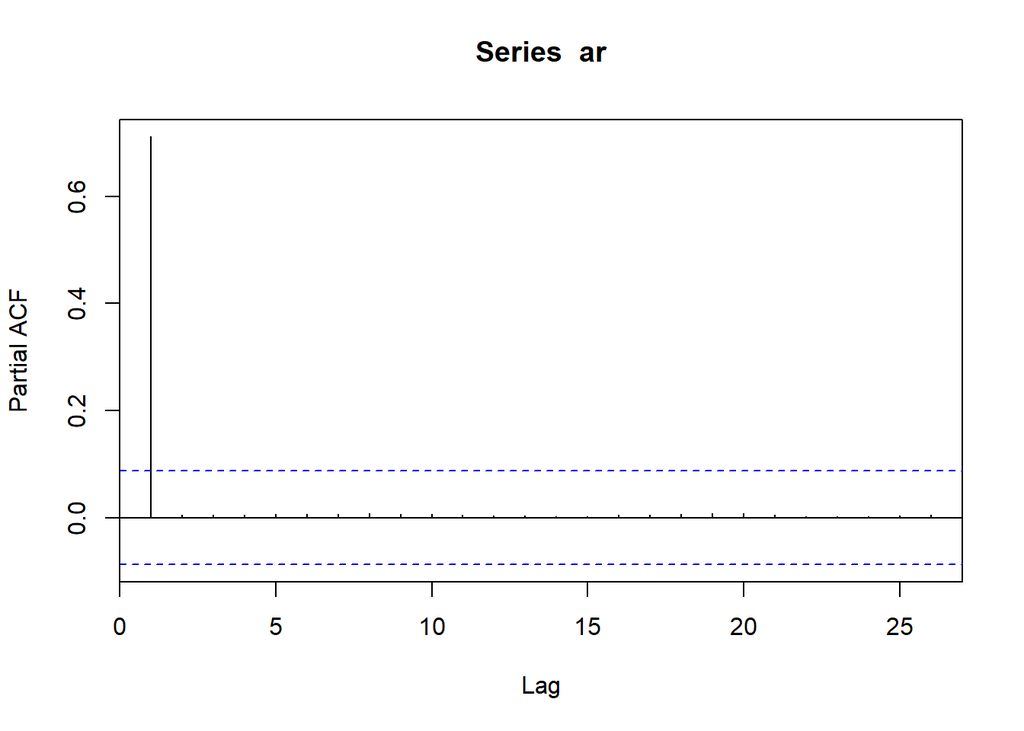

```r
pacf(ar)
```

Berdasarkan plot PACF tersebut, terlihat bahwa plot PACF *cuts off* pada lag pertama, sejalan dengan teori yang ada

### Plot EACF

```r
TSA::eacf(ar)
```

```
## AR/MA
##   0 1 2 3 4 5 6 7 8 9 10 11 12 13
## 0 x x x x x x x x o o o  o  o  o
## 1 x x x x x x x o o o o  o  o  o
## 2 o x x x o o o o o o o  o  o  o
## 3 o o o x o o o o o o o  x  o  o
## 4 x x o x o o o o o o o  o  o  o
## 5 x x x x o o x o o o x  o  o  o
## 6 x x x x o o o o o o x  o  o  o
## 7 x o x x x o o o o o o  o  o  o
```

#### Plot ACF

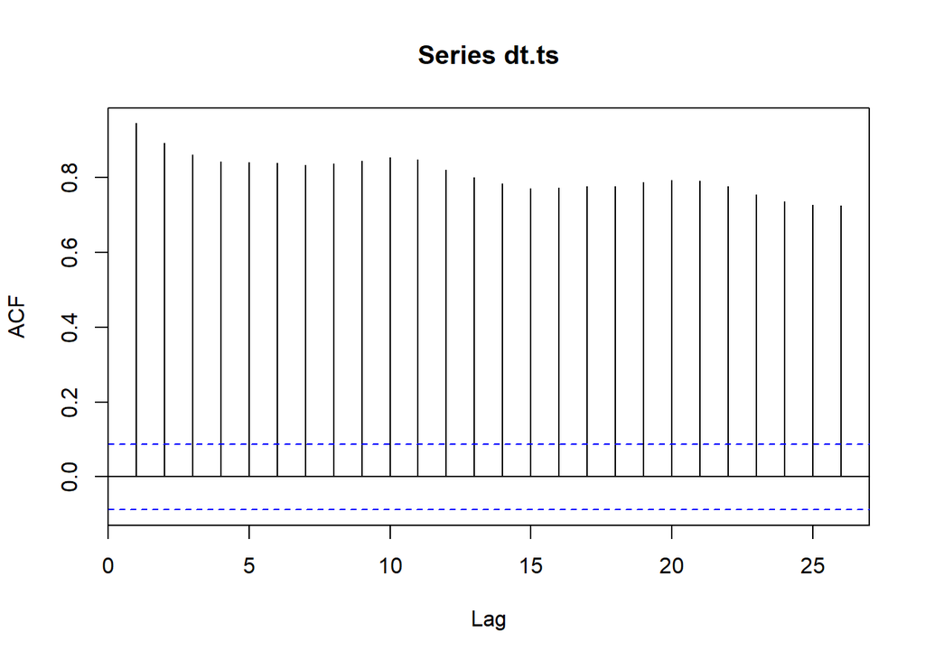

```r
acf(dt.ts)
```

Berdasarkan plot ACF, terlihat bahwa plot ACF data menurun secara perlahan (*tails of slowly*). Hal ini juga menjadi indikasi bahwa data tidak stasioner dalam rataan

## Uji ADF

```r
tseries::adf.test(dt.ts)
```

```
##
##  Augmented Dickey-Fuller Test
##
## data:  dt.ts
## Dickey-Fuller = -3.1086, Lag order = 7, p-value = 0.1091
## alternative hypothesis: stationary
```

$H_0$ : Data tidak stasioner dalam rataan

$H_1$ : Data stasioner dalam rataan

Berdasarkan uji ADF tersebut, didapat *p-value* sebesar 0.1091 yang lebih besar dari taraf nyata 5% sehingga tak tolak $H_0$ dan menandakan bahwa data tidak stasioner dalam rataan. Hal ini sesuai dengan hasil eksplorasi menggunakan plot time series dan plot ACF, sehingga ketidakstasioneran model kedepannya harus ditangani

#### Plot Box-Cox

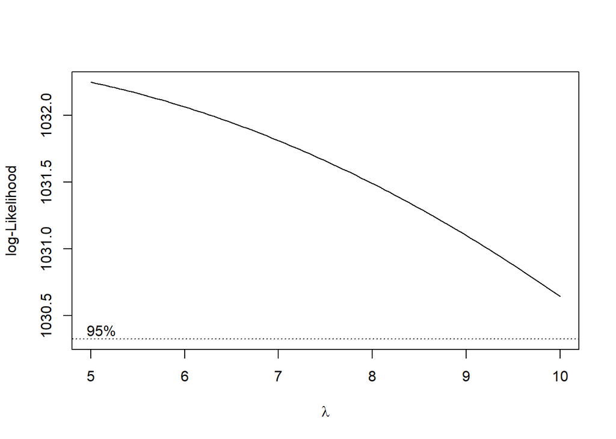

```r
index <- seq(1:500)
bc = boxcox(dt.ts~index, lambda = seq(5,10,by=1))
```

```r
#Nilai Rounded Lambda
lambda <- bc$x[which.max(bc$y)]
lambda
```

```
## [1] 5
```

```r
#SK
bc$x[bc$y > max(bc$y) - 1/2 * qchisq(.95,1)]
```

```
##   [1]  5.000000  5.050505  5.101010  5.151515  5.202020  5.252525  5.303030
##   [8]  5.353535  5.404040  5.454545  5.505051  5.555556  5.606061  5.656566
##  [15]  5.707071  5.757576  5.808081  5.858586  5.909091  5.959596  6.010101
##  [22]  6.060606  6.111111  6.161616  6.212121  6.262626  6.313131  6.363636
##  [29]  6.414141  6.464646  6.515152  6.565657  6.616162  6.666667  6.717172
##  [36]  6.767677  6.818182  6.868687  6.919192  6.969697  7.020202  7.070707
##  [43]  7.121212  7.171717  7.222222  7.272727  7.323232  7.373737  7.424242
##  [50]  7.474747  7.525253  7.575758  7.626263  7.676768  7.727273  7.777778
##  [57]  7.828283  7.878788  7.929293  7.979798  8.030303  8.080808  8.131313
##  [64]  8.181818  8.232323  8.282828  8.333333  8.383838  8.434343  8.484848
##  [71]  8.535354  8.585859  8.636364  8.686869  8.737374  8.787879  8.838384
##  [78]  8.888889  8.939394  8.989899  9.040404  9.090909  9.141414  9.191919
##  [85]  9.242424  9.292929  9.343434  9.393939  9.444444  9.494949  9.545455
##  [92]  9.595960  9.646465  9.696970  9.747475  9.797980  9.848485  9.898990
##  [99]  9.949495 10.000000
```

### Penanganan Ketidakstasioneran Data

Data di diferencing 2 kali

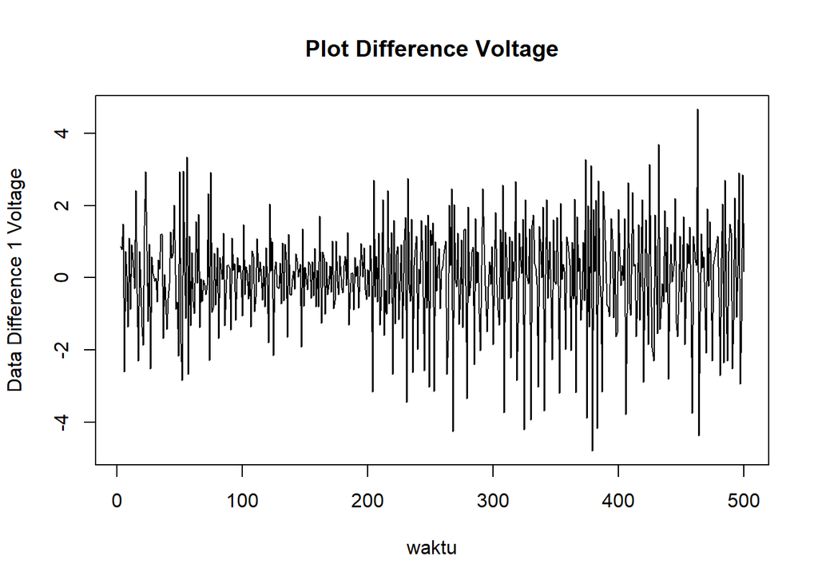

```r
dt.diff<-diff(dt.ts,differences = 2)
plot.ts(dt.diff, lty=1, xlab="waktu", ylab="Data Difference 1 Voltage", main="Plot Difference Voltage")
```

Berdasarkan plot data deret waktu, terlihat bahwa data sudah stasioner dalam rataan ditandai dengan data bergerak pada nilai tengah tertentu (tidak terdapat trend ataupun musiman pada data)

#### Plot ACF

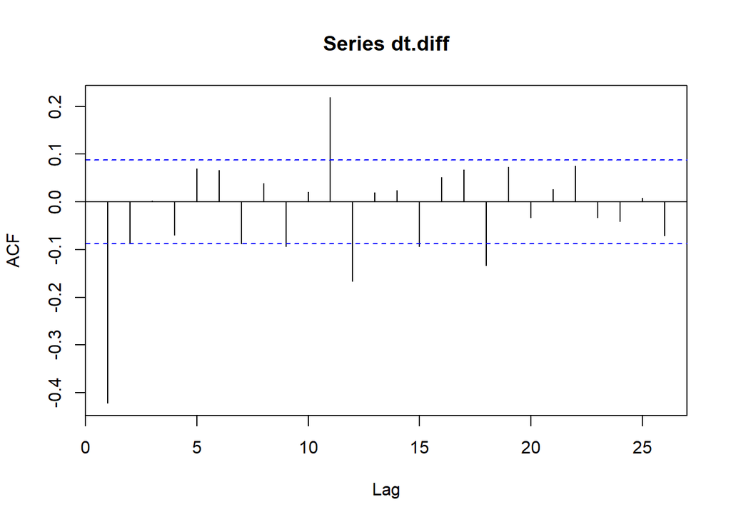

```r
acf(dt.diff)
```

#### Plot PACF

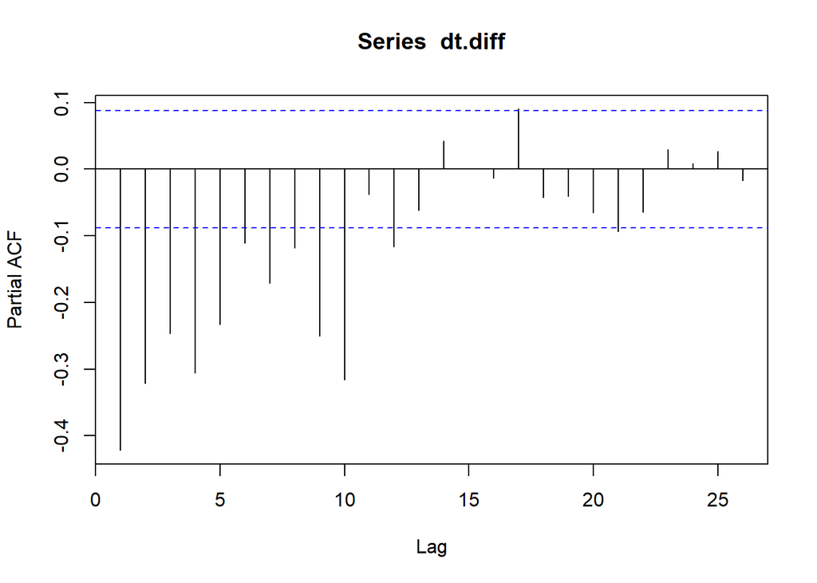

```r
pacf(dt.diff)
```

#### Plot EACF

```r
eacf(dt.diff)
```

```
## AR/MA
##   0 1 2 3 4 5 6 7 8 9 10 11 12 13
## 0 x o o o o o o o x o x  x  o  o
## 1 x x o o o x o o x o x  x  o  o
## 2 x x o o o x o o o o x  x  o  o
## 3 x x x x o o o o o o x  x  x  x
## 4 x x x x x o o o o o x  x  o  x
## 5 x x x x x x o o o o x  o  o  x
## 6 x x x o x x o o o o x  o  o  o
## 7 x x x o x x o o o o x  x  o  o
```

Identifikasi model menggunakan plot EACF dilakukan dengan melihat ujung segitiga pada pola segitiga nol. Dalam hal ini model tentatif yang terbentuk adalah ARIMA(0,1,1), ARIMA(1,1,2), ARIMA(0,1,2).

### Pendugaan Parameter Model Tentatif

#### ARIMA(0,1,1)

```r
model1.da=Arima(dt.diff, order=c(0,1,1),method="ML")
summary(model1.da) #AIC=1811.52
```

```
## Series: dt.diff
## ARIMA(0,1,1)
##
## Coefficients:
##          ma1
##       -1.000
## s.e.   0.005
##
## sigma^2 = 2.2:  log likelihood = -903.76
## AIC=1811.52   AICc=1811.55   BIC=1819.94
##
## Training set error measures:
##                       ME     RMSE      MAE      MPE     MAPE      MASE
## Training set -0.01240796 1.480296 1.131582 99.55073 100.7771 0.5855124
##                    ACF1
## Training set -0.4211822
```

```r
lmtest::coeftest(model1.da)
```

```
##
## z test of coefficients:
##
##       Estimate Std. Error z value  Pr(>|z|)
## ma1 -0.9999999  0.0050212 -199.16 < 2.2e-16 ***
## ---
## Signif. codes:  0 '***' 0.001 '**' 0.01 '*' 0.05 '.' 0.1 ' ' 1
```

#### ARIMA(1,1,2)

```r
model2.da=Arima(dt.diff, order=c(1,1,2),method="ML")
summary(model2.da) #AIC=1475.9
```

```
## Series: dt.diff
## ARIMA(1,1,2)
##
## Coefficients:
##           ar1      ma1     ma2
##       -0.0143  -1.9985  0.9994
## s.e.   0.0451   0.0214  0.0215
##
## sigma^2 = 1.09:  log likelihood = -733.95
## AIC=1475.9   AICc=1475.98   BIC=1492.74
##
## Training set error measures:
##                        ME     RMSE       MAE      MPE     MAPE      MASE
## Training set -0.005992443 1.039703 0.7894736 74.96515 164.2983 0.4084958
##                      ACF1
## Training set -0.002594634
```

```r
lmtest::coeftest(model2.da)
```

```
##
## z test of coefficients:
##
##      Estimate Std. Error  z value Pr(>|z|)
## ar1 -0.014268   0.045116  -0.3162   0.7518
## ma1 -1.998482   0.021444 -93.1933   <2e-16 ***
## ma2  0.999436   0.021455  46.5821   <2e-16 ***
## ---
## Signif. codes:  0 '***' 0.001 '**' 0.01 '*' 0.05 '.' 0.1 ' ' 1
```

#### ARIMA(0,1,2)

```r
model3.da=Arima(dt.diff, order=c(0,1,2),method="ML")
summary(model3.da) #AIC=1479.7
```

```
## Series: dt.diff
## ARIMA(0,1,2)
##
## Coefficients:
##           ma1     ma2
##       -1.9749  0.9758
## s.e.   0.0193  0.0194
##
## sigma^2 = 1.111:  log likelihood = -736.85
## AIC=1479.7   AICc=1479.75   BIC=1492.33
##
## Training set error measures:
##                        ME     RMSE       MAE      MPE     MAPE      MASE
## Training set -0.005273358 1.050674 0.7968031 74.97025 162.1899 0.4122883
##                     ACF1
## Training set -0.01694636
```

```r
lmtest::coeftest(model3.da)
```

```
##
## z test of coefficients:
##
##      Estimate Std. Error  z value  Pr(>|z|)
## ma1 -1.974933   0.019277 -102.451 < 2.2e-16 ***
## ma2  0.975777   0.019382   50.344 < 2.2e-16 ***
## ---
## Signif. codes:  0 '***' 0.001 '**' 0.01 '*' 0.05 '.' 0.1 ' ' 1
```

### Analisis Sisaan

#### Eksplorasi Sisaan

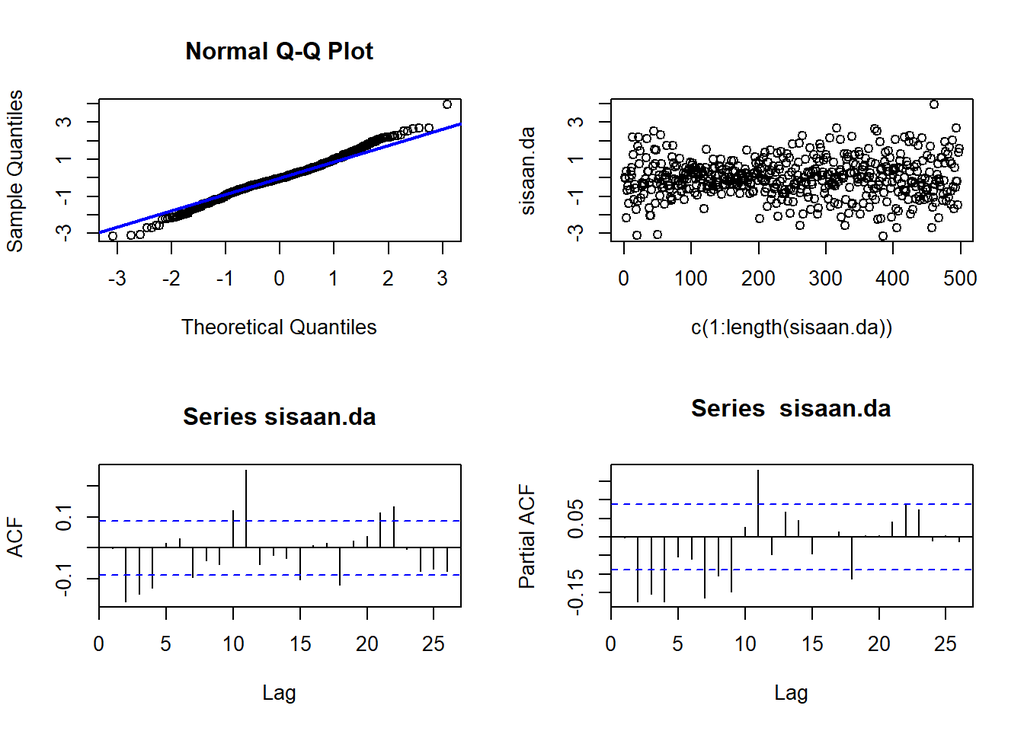

```r
#Eksplorasi
sisaan.da <- model2.da$residuals
par(mfrow=c(2,2))
qqnorm(sisaan.da)
qqline(sisaan.da, col = "blue", lwd = 2)
plot(c(1:length(sisaan.da)),sisaan.da)
acf(sisaan.da)
pacf(sisaan.da)
```

```r
par(mfrow = c(1,1))
```

Berdasarkan plot kuantil-kuantil normal, secara eksplorasi ditunjukkan sisaan menyebar normal ditandai dengan titik titik yang cenderung mengikuti garis $45^{\circ}$.

#### Uji Formal

```r
#1) Sisaan Menyebar Normal
ks.test(sisaan.da,"pnorm")  #tak tolak H0 > sisaan menyebar normal
```

```
##
##  Asymptotic one-sample Kolmogorov-Smirnov test
##
## data:  sisaan.da
## D = 0.039252, p-value = 0.4268
## alternative hypothesis: two-sided
```

Selain dengan eksplorasi, asumsi tersebut dapat diuji menggunakan uji formal. Pada tahapan ini uji formal yang digunakan untuk normalitas adalah uji Kolmogorov-Smirnov (KS). Hipotesis pada uji KS adalah sebagai berikut.

$H_0$ : Sisaan menyebar normal

$H_1$ : Sisaan tidak menyebar normal